# Brooklyn Nets Data Scientist Basketball Project

### Ruslan Davtian

```python
%%html
<script>
function toggleCode() {
  var selectors = [
    'div.cell.code_cell div.input',        // classic nbconvert template, code cells only
    '.jp-CodeCell .jp-InputArea',           // lab-style template, code cells only
    '.jp-CodeCell .jp-Cell-inputWrapper'    // lab-style template, alt structure, code cells only
  ];
  var found = false;
  selectors.forEach(function(sel) {
    var els = document.querySelectorAll(sel);
    if (els.length > 0) {
      found = true;
      els.forEach(function(el) { el.style.display = (el.style.display === 'none' ? '' : 'none'); });
    }
  });
  if (!found) { alert('No code cells found to toggle — check the console for the actual class name used in this export.'); }
}
</script>
<button onclick="toggleCode()" style="padding:6px 14px; font-size:14px; cursor:pointer;">
  Toggle code visibility
</button>
```

```python
import plotly.io as pio
# Tells Plotly to inject full interactive capabilities into the notebook's HTML export structure
pio.renderers.default = "notebook"

from plotly.offline import init_notebook_mode
# Activates the underlying javascript hooks required during the HTML bundle phase
init_notebook_mode(connected=True)
```

## Building an NBA Win Probability Model for Front Office Decision-Making

```python
## Library/Package Imports

#pip install sportsdataverse[all]
#pip install shap
from sportsdataverse.nba import load_nba_pbp, load_nba_team_boxscore, espn_nba_game_odds, espn_nba_summary, espn_nba_player_info, load_nba_rosters
import pandas as pd
import numpy as np
import xgboost as xgb
from sklearn.metrics import (
    ConfusionMatrixDisplay, accuracy_score, brier_score_loss, classification_report,
    confusion_matrix, f1_score, log_loss, precision_score, recall_score,
)
from sklearn.model_selection import GridSearchCV, GroupKFold
import matplotlib.pyplot as plt
import shap
from scipy import stats
import seaborn as sns
from IPython.display import display, HTML, YouTubeVideo
import plotly.express as px
```

```python
# Function to view entire column space of dataframe and control number of rows to print
def view_full_df(df, max_rows_to_print, num_rows_to_print):
    print("DF Shape:", df.shape[0], "rows and", df.shape[1], "cols")
    with pd.option_context('display.max_rows', max_rows_to_print, 'display.max_columns', None):
        display(df.head(num_rows_to_print))

# Function that given a dataframe, it displays the percentage of missing values for each column
def missing_values_table(df):
    miss_val = df.isnull().sum()
    miss_val_percent = 100 * df.isnull().sum() / len(df)
    miss_val_table = pd.concat([miss_val, miss_val_percent], axis=1)
    miss_val_table_ren_columns = miss_val_table.rename(
    columns = {0 : 'Missing Values', 1 : '% of Total Values'})
    miss_val_table_ren_columns = miss_val_table_ren_columns[
        miss_val_table_ren_columns.iloc[:,1] != 0].sort_values(
    '% of Total Values', ascending=False).round(1)
    print ("Your selected dataframe has " + str(df.shape[1]) + " columns.\n"
        "There are " + str(miss_val_table_ren_columns.shape[0]) +
            " columns that have missing values.")
    return miss_val_table_ren_columns

# Function to convert moneyline american odds into probability
def american_to_prob(odds_series):
  abs_odds = np.abs(odds_series)
  return np.where(odds_series > 0, 100 / (odds_series + 100), abs_odds / (abs_odds + 100))

# Use sportsdataverse package to scrape seasons of NBA play by play data
def get_nba_pbp_data(seasons):
    pbp = load_nba_pbp(seasons = seasons, return_as_pandas=True)

    # sort games for each game in sequential order
    pbp = pbp.sort_values(["season","game_id","period_number","start_quarter_seconds_remaining"], ascending=[True, True, True, False])

    # create two new columns of home and away score lagged by 1 so we get the score at the start of the possession
    pbp["home_score_lag"] = pbp.groupby("game_id")["home_score"].shift(1)
    pbp["away_score_lag"] = pbp.groupby("game_id")["away_score"].shift(1)

    # first play of the game has no prior state -- it's 0-0
    pbp["home_score_lag"] = pbp["home_score_lag"].fillna(0)
    pbp["away_score_lag"] = pbp["away_score_lag"].fillna(0)

    # compute the score diff (score diff after possession completes and score diff lagged for the score diff at the start of the possession)
    pbp['score_diff'] = pbp['home_score'] - pbp['away_score']
    pbp['score_diff_lag']= pbp['home_score_lag'] - pbp['away_score_lag']

    # is playoffs flag
    pbp['is_playoffs'] = np.where(pbp['season_type'] > 2, 1, 0)

    # return these columns of interest
    cols_to_return = ['season','game_date','team_id','home_team_id','home_team_abbrev','away_team_id','away_team_abbrev','season_type','game_id','game_play_number','sequence_number',
                      'type_id','type_text','text','athlete_id_1','away_score','home_score','score_diff','away_score_lag','home_score_lag','score_diff_lag','period_number',
                      'clock_display_value','scoring_play','shooting_play','score_value','points_attempted','short_description','start_quarter_seconds_remaining',
                      'start_half_seconds_remaining','start_game_seconds_remaining','home_team_mascot','away_team_mascot','is_playoffs']
    return pbp[cols_to_return]

# function to find how many timeouts are allocated for home and away teams with OT in mind and compute how many timeouts each side has available to the lagged (start of each possession)
def compute_timeouts_remaining(df, game_col = "game_id", period_col = "period_number", order_col="start_quarter_seconds_remaining"):
    df = df.sort_values([game_col, period_col, order_col], ascending=[True, True, False]).copy()
    ot_periods = (df[period_col] - 4).clip(lower=0)
    df["timeout_allotment"] = 7 + 2 * ot_periods
    for side in ["home", "away"]:
        called_col = f"{side}_timeout_called"
        cum_inclusive = df.groupby(game_col)[called_col].cumsum()
        used_before_this_row = cum_inclusive - df[called_col].astype(int)
        df[f"{side}_timeouts_remaining_lag"] = df["timeout_allotment"] - used_before_this_row
    return df

# function to scrape pregame closing spread and moneyline odds for every game to use as a pregame prior of matchup strength and home win prob
def get_nba_pregame_closing_spread(game_ids):
    df = []
    for game_id in game_ids:
        odds = espn_nba_game_odds(event_id = game_id, return_as_pandas=True)
        odds["game_id"] = game_id
        df.append(odds)
    odds_df = pd.concat(df, ignore_index=True)
    cols_to_return =  ["game_id","spread","home_team_odds_favorite","away_team_odds_money_line","home_team_odds_money_line","provider_name"]
    return odds_df[cols_to_return]

# function to scrape end of game results (home team won) as well as final margin of victory
# also compute rolling cumulative pregame win percentages and avg point differential as pregame priors as well
def get_nba_rolling_standings(seasons):
    df = load_nba_team_boxscore(seasons = seasons, return_as_pandas=True)
    df = df.sort_values(["season","team_id","game_date"])
    df["score_diff"] = df["team_score"] - df["opponent_team_score"]
    df["win"] = np.where(df["team_score"] > df["opponent_team_score"], 1, 0)
    df["loss"] = np.where(df["team_score"] < df["opponent_team_score"], 1, 0)
    df["home_team_won"] = np.where((df["team_home_away"] == "home") & (df["team_winner"]==True), 1,
                          np.where((df["team_home_away"] == "away") & (df["team_winner"]==False), 1, 0))

    df["pregame_w"] = df.groupby(["season","team_id"])["win"].transform(lambda x: x.shift(1).cumsum())
    df["pregame_l"] = df.groupby(["season","team_id"])["loss"].transform(lambda x: x.shift(1).cumsum())
    df["pregame_gp"] = df["pregame_w"].fillna(0) + df["pregame_l"].fillna(0)
    df["pregame_w_pct"] = (df["pregame_w"] / df["pregame_gp"]).fillna(0.5)
    df["pregame_point_diff_avg"] = df.groupby(["season","team_id"])["score_diff"].transform(lambda x: x.shift(1).expanding().mean()).fillna(0.0)
```

```python
    cols_to_return = ["game_id","team_id","pregame_w","pregame_l","pregame_gp","pregame_w_pct","pregame_point_diff_avg","home_team_won"]
    return df[cols_to_return]

# function to compute how much rest (days of rest) for both teams going into the game as well as if the game is the 2nd leg of a back to back
def compute_rest_and_b2b(schedule_long, game_col="game_id", team_col="team_id",
                          date_col="game_date", home_away_col="team_home_away",
                          season_col="season", default_rest=3, cap_rest_at=None):
    df = schedule_long[[game_col, team_col, date_col, home_away_col, season_col]].copy()
    df[date_col] = pd.to_datetime(df[date_col])
    df = df.sort_values([team_col, season_col, date_col])

    df["prev_game_date"] = df.groupby([team_col, season_col])[date_col].shift(1)
    df["rest_days"] = (df[date_col] - df["prev_game_date"]).dt.days
    df["rest_days"] = df["rest_days"].fillna(default_rest)

    if cap_rest_at is not None:
        df["rest_days"] = df["rest_days"].clip(upper=cap_rest_at)

    df["is_back_to_back"] = (df["rest_days"] == 1).astype(int)

    home_rows = df[df[home_away_col] == "home"][[game_col, season_col, team_col, "rest_days", "is_back_to_back"]] \
        .rename(columns={team_col: "home_team_id", "rest_days": "home_rest_days", "is_back_to_back": "home_back_to_back"})
    away_rows = df[df[home_away_col] == "away"][[game_col, team_col, "rest_days", "is_back_to_back"]] \
        .rename(columns={team_col: "away_team_id", "rest_days": "away_rest_days", "is_back_to_back": "away_back_to_back"})

    game_level = home_rows.merge(away_rows, on=game_col, how="inner")
    game_level["rest_days_diff"] = game_level["home_rest_days"] - game_level["away_rest_days"]
    game_level["back_to_back_diff"] = game_level["home_back_to_back"] - game_level["away_back_to_back"]

    return game_level[[game_col,season_col,"home_team_id","away_team_id","home_rest_days", "away_rest_days", "rest_days_diff",
                       "home_back_to_back", "away_back_to_back", "back_to_back_diff"]]

# function to extract espn's play by play win probability for non-all star games to compare against user model forecasts
def get_espn_win_prob(game_ids):
    df = []
    for game_id in game_ids:
        if game_id in (401752955, 401752956, 401752957, 401838140, 401838141, 401838142, 401838143): # skip all star games
            continue
        game_df = espn_nba_summary(event_id = game_id)
        espn_win_prob = game_df.get("winprobability") #extract win probability dataframe
        if espn_win_prob.shape[0] == 0:
            continue
        espn_win_prob = pd.DataFrame(espn_win_prob)
        espn_win_prob.columns = ['espn_home_team_win_prob','tie_prob','sequence_number']
        espn_win_prob["game_id"] = game_id
        espn_win_prob["sequence_number"] = espn_win_prob['sequence_number'].str[9:] #extract the sequence number from event_id + sequence_number concatenated string
        df.append(espn_win_prob)
    win_prob_df = pd.concat(df, ignore_index=True)
    return win_prob_df[["game_id","sequence_number","espn_home_team_win_prob"]]

# function that creates a biserial correlation plot against a binary target variable vs list of numeric features
def plot_feature_correlation_vs_target(df, numerical_features):
    correlations = {}
    for col in numerical_features:
        if col == 'pregame_home_team_w_prob':
            r_pb, _ = stats.pointbiserialr(df[~df[col].isna()][col], df[~df[col].isna()]["home_team_won"])

        else:
            r_pb, _ = stats.pointbiserialr(df[col], df["home_team_won"])
        correlations[col] = r_pb
    corr_series = pd.Series(correlations).sort_values()
    plt.figure(figsize=(10, 5))
    sns.barplot(x = corr_series.values,y = corr_series.index)
    plt.axvline(0, color="black", linestyle="--", linewidth=1)
    plt.xlim(-1, 1)  # Correlation bounds
    plt.xlabel("Point-Biserial Correlation Coefficient")
    plt.ylabel("Features")
    plt.title("Feature Correlation with Home Team Won (0 = Loss, 1 = Win)")
    plt.grid(axis="x", linestyle=":", alpha=0.6)
    plt.tight_layout()
    plt.show()

# function to split modeling dataset into train/test split by season and use 5 fold cross validation grouped by event_id on test set
# implement grid search hyper-parameter tuning optimized on log loss and predict on test set/compute error metrics (espn win prob as a comparison)
# print out confusion table, error metrics, and use predictions (1 play lagged) and create 1 play lead (predictions) to take difference to compute WPA (win probability added)
def run_nba_wp_model(df, train_season, test_season, feature_cols, param_grid, n_splits=5):
    train_df = df[df['season'] == train_season].reset_index(drop=True)
    test_df = df[df['season'] == test_season].reset_index(drop=True)

    print("Train X's Dim: ", train_df[feature_cols].shape)
    print("Train Y Dim: ", train_df[y_col].shape)
    print("Test X's Dim: ", test_df[feature_cols].shape)
    print("Test Y Dim: ", test_df[y_col].shape)
    print("Total Rows: ", train_df[feature_cols].shape[0] + test_df[feature_cols].shape[0])

    grid_search = GridSearchCV(
        estimator=xgb.XGBClassifier(objective="binary:logistic", eval_metric="logloss", tree_method="hist"),
        param_grid=param_grid,
        scoring="neg_log_loss",
        cv=GroupKFold(n_splits=n_splits),
        refit=True, # automatically refits best_estimator_ on ALL of train_df
        verbose=1,
    )
    grid_search.fit(train_df[feature_cols], train_df[y_col], groups=train_df['game_id'])

    print(f"Best CV logloss: {-grid_search.best_score_:.4f}")
    print(f"Best params: {grid_search.best_params_}")

    model = grid_search.best_estimator_   # the raw fitted XGBoost model, refit on all of train_df

    # attach predictions directly onto test_df so it can be saved and reused
    # later (SHAP, calibration curves, importance, etc.) without rerunning
    # the whole pipeline
    test_df = test_df.copy()
    test_df["pred"] = model.predict_proba(test_df[feature_cols])[:, 1]
    test_df["pred_binary"] = np.where(test_df["pred"] >= 0.5, 1, 0)
```

```python
    cm = confusion_matrix(test_df[y_col].values, test_df["pred_binary"].values)
    cm_pct = cm / cm.sum(axis=1, keepdims=True)

    metrics = {
        "accuracy": accuracy_score(test_df[y_col].values, test_df["pred_binary"].values),
        "precision": precision_score(test_df[y_col].values, test_df["pred_binary"].values),
        "recall": recall_score(test_df[y_col].values, test_df["pred_binary"].values),
        "f1": f1_score(test_df[y_col].values, test_df["pred_binary"].values),
        "logloss": log_loss(test_df[y_col].values, test_df["pred"].values),
        "brier": brier_score_loss(test_df[y_col].values, test_df["pred"].values),
    }

    test_df2 = test_df[~test_df['espn_home_team_win_prob'].isna()]

    metrics_espn = {
        "accuracy": accuracy_score(test_df2[y_col].values, test_df2["espn_home_team_win_binary"].values),
        "precision": precision_score(test_df2[y_col].values, test_df2["espn_home_team_win_binary"].values),
        "recall": recall_score(test_df2[y_col].values, test_df2["espn_home_team_win_binary"].values),
        "f1": f1_score(test_df2[y_col].values, test_df2["espn_home_team_win_binary"].values),
        "logloss": log_loss(test_df2[y_col].values, test_df2["espn_home_team_win_prob"].values),
        "brier": brier_score_loss(test_df2[y_col].values, test_df2["espn_home_team_win_prob"].values),
    }

    print("\n=== Test set performance ===")
    for k, v in metrics.items():
        print(f"{k:>10}: {v:.4f}")

    print("\n=== ESPN Win Prob Test set performance ===")
    for k, v in metrics_espn.items():
        print(f"{k:>10}: {v:.4f}")

    print("\n=== Classification report (threshold = {:.2f}) ===".format(0.5))
    print(classification_report(test_df[y_col].values, test_df["pred_binary"].values, target_names=["Away win", "Home win"]))

    labels = ["Away win", "Home win"]
    fig, axes = plt.subplots(1, 2, figsize=(11, 4.5))

    ConfusionMatrixDisplay.from_predictions(
        test_df[y_col].values, test_df["pred_binary"].values, display_labels=labels, normalize=None,
        cmap="Blues", ax=axes[0], colorbar=False,
    )
    axes[0].set_title("Confusion matrix (counts)")

    ConfusionMatrixDisplay.from_predictions(
        test_df[y_col].values, test_df["pred_binary"].values, display_labels=labels, normalize="true",
        cmap="Blues", ax=axes[1], colorbar=False,
    )
    axes[1].set_title("Confusion matrix (row %)")

    plt.tight_layout()
    plt.show()

    test_df = test_df.rename(columns={"pred": "pred_home_team_win_prob_lag", "pred_binary": "pred_home_team_win_binary_lag"})

    # compute win probability added based on pre and post possession home team win probability for each game
    test_df = test_df.sort_values(["season","game_id","sequence_number"], ascending=[True, True, True])
    test_df["pred_home_team_win_prob"] = test_df.groupby("game_id")["pred_home_team_win_prob_lag"].shift(-1)
    is_last_play = test_df.groupby("game_id").cumcount(ascending=False) == 0
    test_df.loc[is_last_play, "pred_home_team_win_prob"] = test_df.loc[is_last_play, "home_team_won"].astype(float)
    test_df.loc[is_last_play, "pred_home_team_win_prob_lag"] = test_df.loc[is_last_play, "espn_home_team_win_prob"].astype("float32")
    test_df["win_probability_added_home_team"] = test_df["pred_home_team_win_prob"] - test_df["pred_home_team_win_prob_lag"]
    test_df["win_probability_added_away_team"] = -test_df["win_probability_added_home_team"]
    test_df["win_probability_added"] = np.where(test_df['is_home'] == 1, test_df["win_probability_added_home_team"], test_df["win_probability_added_away_team"])

    return {
        "model": model,
        "grid_search": grid_search,
        "best_params": grid_search.best_params_,
        "metrics": metrics,
        "confusion_matrix": cm,
        "confusion_matrix_pct": cm_pct,
        "test_df": test_df
    }

# function to scrape player level metadata (names, age, position, number of years in NBA)
def get_player_metadata(seasons):
    players = pd.DataFrame(load_nba_rosters(seasons)[['season','athlete_id','display_name','position_abbreviation','age','experience_years']])
    players.columns = ['season','athlete_id_1','player_name','position','age','experience']
    players['athlete_id_1'] = players['athlete_id_1'].astype(int)
    players['age'] = players['age'].astype(int)
    players['experience'] = players['experience'].astype('Int64')
    return players

# function to plot model prediction calibration (avg actual vs avg pred across prediction bins)
def plot_calibration(y_true, y_pred, width, height, n_bins=10):
    display(HTML("<style>.output_png { display: flex; justify-content: center; }</style>"))

    bins = pd.qcut(y_pred, n_bins, duplicates="drop")
    df = pd.DataFrame({"y_true": np.asarray(y_true), "y_pred": np.asarray(y_pred), "bin": bins})
    grouped = df.groupby("bin", observed=True).agg(
        avg_pred=("y_pred", "mean"),
        avg_actual=("y_true", "mean"),
    )

    fig, ax = plt.subplots(figsize=(width, height))
    ax.plot([0, 1], [0, 1], linestyle="--", color="gray", linewidth=1)
    ax.plot(grouped["avg_pred"], grouped["avg_actual"], marker="o")
    ax.set_xlabel("Predicted Home Team Win Probability")
    ax.set_ylabel("Actual Home Team Win Rate")
    ax.set_xlim(-0.02, 1.02)
    ax.set_ylim(-0.02, 1.02)
    ax.set_title("Calibration Curve of Home Team Win Probability")

    plt.tight_layout()
    plt.show()

"""
2D heatmap of mean |WPA| by game state: seconds left in game (x-axis) vs.
score margin (y-axis). Should show |WPA| concentrated where time is low
and margin is small (the corner where a single play can still swing the
outcome), fading out everywhere else -- the same "urgency" shape discussed
earlier in this build, now visualized directly from real WPA values instead
of the theoretical margin_x_urgency transform.
"""
def plot_wpa_heatmap(df, n_time_bins, time_col="start_game_seconds_remaining", margin_col="score_diff_lag", wpa_col="win_probability_added"):
    plot_df = df.copy()
    plot_df["abs_wpa"] = plot_df[wpa_col].abs()
    plot_df["time_bin"] = pd.cut(plot_df[time_col], n_time_bins)
```

```python
    margin_edges = np.arange(-24, 24, 3)
    plot_df["margin_bin"] = pd.cut(plot_df[margin_col], margin_edges)

    pivot = plot_df.groupby(["margin_bin", "time_bin"], observed=True)["abs_wpa"].mean().unstack()

    counts = pd.crosstab(plot_df["margin_bin"], plot_df["time_bin"])  # no margins, for masking
    min_n = 100
    pivot = pivot.where(counts.reindex_like(pivot) >= min_n, 0)  # low-sample cells -> 0 -> renders black

    fig, ax = plt.subplots(figsize=(8, 6))
    im = ax.imshow(pivot.values, aspect="auto", origin="lower", cmap="magma")

    ax.set_xticks(range(len(pivot.columns)))
    ax.set_xticklabels([f"{iv.mid:.0f}" for iv in pivot.columns], rotation=90, fontsize=7)
    ax.set_yticks(range(len(pivot.index)))
    ax.set_yticklabels([f"{iv.mid:.0f}" for iv in pivot.index], fontsize=7)

    ax.set_xlabel("Seconds Left In Game")
    ax.set_ylabel("Score Diff Lag (Home - Away Lagged)")
    ax.set_title("Mean |WPA| by Game State")
    ax.invert_xaxis()  # time runs start (left) -> buzzer (right)

    fig.colorbar(im, ax=ax, label="Mean |WPA|")
    plt.tight_layout()
    plt.show()

def overlaid_calibration(df, model_col="pred_home_team_win_binary_lag", espn_col="espn_home_team_win_prob", outcome_col="home_team_won", n_bins=8):
    """Both model's and ESPN's calibration curves on the same axes against
    the actual outcome -- the more important comparison of the two."""
    fig, ax = plt.subplots(figsize=(6, 6))
    ax.plot([0, 1], [0, 1], linestyle="--", color="gray", linewidth=1)

    for col, label, color in [(model_col, "Model", "tab:blue"), (espn_col, "ESPN", "tab:orange")]:
        bins = pd.qcut(df[col], n_bins, duplicates="drop")
        grouped = df.groupby(bins, observed=True).agg(
            avg_pred=(col, "mean"), avg_actual=(outcome_col, "mean")
        )
        ax.plot(grouped["avg_pred"], grouped["avg_actual"], marker="o", label=label, color=color)

    ax.set_xlabel("Predicted probability")
    ax.set_ylabel("Actual win rate")
    ax.set_title("Calibration: model vs. ESPN (pregame predictions)")
    ax.legend()
    plt.tight_layout()
    plt.show()

def plot_first_play_correlation(df, x_col="pregame_home_team_w_prob", y_col="pred_home_team_win_prob_lag", game_col="game_id", seq_col="sequence_number"):
    first_play = df.loc[df.groupby(game_col)[seq_col].idxmin()].copy()
    first_play = first_play.dropna(subset=[x_col, y_col, "home_team_won"])

    slope, intercept, r, p_value, se = stats.linregress(first_play[x_col], first_play[y_col])

    fig, ax = plt.subplots(figsize=(7, 6))

    colors = np.where(first_play["home_team_won"] == 1, "green", "black")
    ax.scatter(first_play[x_col], first_play[y_col], alpha=0.5, s=15, c=colors)
    # dummy handles so the legend shows clean labeled colors instead of a
    # per-point mix pulled from the actual scatter call
    ax.scatter([], [], color="green", label="home_team_won = 1")
    ax.scatter([], [], color="black", label="home_team_won = 0")

    x_line = np.linspace(first_play[x_col].min(), first_play[x_col].max(), 100)
    ax.plot(x_line, slope * x_line + intercept, color="red", linewidth=2, label="regression line")

    ax.text(0.05, 0.95, f"r = {r:.3f}", transform=ax.transAxes,
            va="top", ha="left", fontsize=13,
            bbox=dict(boxstyle="round", facecolor="white", alpha=0.8))

    ax.set_xlabel(x_col)
    ax.set_ylabel(y_col)
    ax.set_title(f"First play: {y_col} vs {x_col}")
    ax.legend(loc="lower right", fontsize=9)
    plt.tight_layout()
    plt.show()

# HTML code to force plots to be plotted in the middle of cell code block
def print_plot_middle():
    display(HTML("""
    <style>
    .jp-OutputArea-output, .output_png, .output_subarea {
        display: flex !important;
        justify-content: center !important;
        align-items: center !important;
    }
    </style>
    """))

def aggregate_player_wpa(df, player_col="player_name", wpa_col="win_probability_added"):
    """
    Returns a player-level dataframe with wpa_total, possessions (play count
    attributed to this player), and wpa_per_100 -- ready to feed directly
    into plot_wpa_leaderboard / plot_wpa_quadrant.
    """
    work = df.dropna(subset=[player_col, wpa_col, 'position']).copy()
    player_df = work.groupby([player_col, 'position']).agg(
        wpa_total=(wpa_col, "sum"),
        possessions=(wpa_col, "size"),
    ).reset_index()
    player_df["wpa_per_100"] = player_df["wpa_total"] / player_df["possessions"] * 100
    return player_df.sort_values("wpa_total", ascending=False)

"""
plot_wpa_leaderboard()  -- top N by total WPA vs. top N by WPA/100,side by side (different rankings expected)
"""
def plot_wpa_leaderboard(player_df, name_col="player_name", total_col="wpa_total",
                          rate_col="wpa_per_100", n=20):
    """Two side-by-side horizontal bar charts: top N by total WPA, top N by
    WPA per 100 possessions. Different rankings on each side is expected --
    it's the opportunity-vs-rate distinction discussed earlier."""
    player_df = player_df[player_df['possessions']>=200]
    fig, axes = plt.subplots(1, 2, figsize=(13, max(5, n * 0.35)))

    top_total = player_df.sort_values(total_col, ascending=True).tail(n)
    axes[0].barh(top_total[name_col], top_total[total_col], color="steelblue")
    axes[0].set_title(f"Top {n} by total WPA")
    axes[0].set_xlabel("Total WPA")

    top_rate = player_df.sort_values(rate_col, ascending=True).tail(n)
    axes[1].barh(top_rate[name_col], top_rate[rate_col], color="darkorange")
    axes[1].set_title(f"Top {n} by WPA per 100 possessions")
    axes[1].set_xlabel("WPA per 100 possessions")

    plt.tight_layout()
    plt.show()

"""
Interactive version of the WPA efficiency/opportunity quadrant chart using
Plotly -- hover over any bubble to see the player name and exact values.
"""
def plot_wpa_quadrant_plotly(player_df, name_col="player_name", total_col="wpa_total",
                              rate_col="wpa_per_100", possession_col="possessions",n_label=30):
    df = player_df.copy()
```

```python
    dist_from_median = (
        (df[rate_col] - df[rate_col].median()).abs() / df[rate_col].std()
        + (df[total_col] - df[total_col].median()).abs() / df[total_col].std()
    )
    label_ids = df.loc[dist_from_median.sort_values(ascending=False).index, name_col].head(n_label)
    df["label_text"] = df[name_col].where(df[name_col].isin(label_ids), "")

    fig = px.scatter(
        df,
        x=rate_col,
        y=total_col,
        size=possession_col,
        text="label_text",
        hover_name=name_col,
        hover_data={rate_col: ":.3f", total_col: ":.3f", possession_col: True, "label_text": False},
        size_max=20,
        opacity=0.6,
        color_discrete_sequence=["teal"],
    )
    fig.update_traces(textposition="top center", textfont_size=9)

    x_med = df[rate_col].median()
    y_med = df[total_col].median()
    fig.add_vline(x=x_med, line_dash="dash", line_color="gray")
    fig.add_hline(y=y_med, line_dash="dash", line_color="gray")

    fig.update_layout(
        title="Player Value Quadrant: Efficiency vs. Total Contribution<br><sub>bubble size = possessions</sub>",
        xaxis_title="WPA per 100 possessions (opportunity-adjusted efficiency)",
        yaxis_title="Total WPA (cumulative, NOT adjusted for opportunity)",
        template="plotly_white",
        width=800,
        height=700,
    )

    fig.show()
    return fig

"""
Plot one game's full win probability trajectory (time on x-axis, home team
win probability on y-axis), then highlight and label the specific plays
made by a chosen player that produced the largest |wpa| swings -- a direct
visual of that player's impact on the game's outcome probability.
"""
def plot_game_win_prob_with_player_highlights(df, game_id, player_name, game_col="game_id",
                                               player_col="player_name", time_col="start_game_seconds_remaining",
                                               pred_col="pred_home_team_win_prob", wpa_col="win_probability_added",
                                               highlight_threshold=0.05, top_n=None, text_col=None):
    """
    highlight selection: if top_n is given, highlight that player's top_n
    plays by |wpa| regardless of threshold. Otherwise, highlight every play
    by that player with |wpa| >= highlight_threshold.

    text_col: optional column name with the play-by-play description text
    (e.g. "Made 3PT Jump Shot", "Turnover: Bad Pass") -- if given, it's
    appended to each highlighted play's annotation for context beyond the
    bare wpa number.
    """
    game_df = df[df[game_col] == game_id].sort_values(time_col, ascending=False).copy()
    if len(game_df) == 0:
        raise ValueError(f"No rows found for game_id={game_id}")

    player_plays = game_df[game_df[player_col] == player_name].copy()
    if top_n is not None:
        highlight = player_plays.reindex(
            player_plays[wpa_col].abs().sort_values(ascending=False).index
        ).head(top_n)
    else:
        highlight = player_plays[player_plays[wpa_col].abs() >= highlight_threshold]

    fig, ax = plt.subplots(figsize=(16, 7))

    ax.plot(game_df[time_col], game_df[pred_col], color="steelblue", linewidth=1.2,
            label="Home Team Win Prob")
    ax.axhline(0.5, color="gray", linestyle=":", linewidth=1)

    colors = np.where(highlight[wpa_col] > 0, "green", "red")
    ax.scatter(highlight[time_col], highlight[pred_col], c=colors, s=70,
               zorder=5, edgecolor="black", linewidth=0.6,
               label=f"{player_name}'s Plays (WPA Highlighted)")

    for _, row in highlight.iterrows():
        label = f"{row[wpa_col]:+.3f}"
        if text_col is not None and pd.notna(row.get(text_col)):
            label += f"\n{row[text_col]}"
        ax.annotate(label, (row[time_col], row[pred_col]),
                    fontsize=10, ha="center", va="bottom")

    ax.set_xlabel("Seconds Left", fontsize = 15)
    ax.set_ylabel("Home Team Win Probability", fontsize = 15)
    ax.set_title(f"Game {game_id}: Win Prob Trajectory, Highlighting {player_name}'s Impact")
    ax.invert_xaxis()  # time flows tipoff (left) -> buzzer (right)
    ax.set_ylim(-0.02, 1.02)
    ax.legend(loc="best", fontsize=10)
    plt.tight_layout()
    plt.show()

    cols = ['game_date','home_team_abbrev','away_team_abbrev','period_number','clock_display_value','home_score','away_score','text','short_description',
            'pred_home_team_win_prob_lag','pred_home_team_win_prob','win_probability_added']
    return view_full_df(highlight[cols].sort_values('win_probability_added', ascending = False), 1000000, 4)

def plot_good_vs_bad_events(df, team_col="team_abbrev", wpa_col="win_probability_added", play_type_col="short_description", top_n_types=6):
    EXPECTED_SIGN = {"+1 Point":1,"+2 Points":1,"+3 Points":1,"Turnover":-1,"Violation":-1,"Foul":-1,"Missed 3PT":-1,"Missed FG":-1,"Missed FT":-1,"Rebound":1,"Goaltending":-1}
    good = [c for c, s in EXPECTED_SIGN.items() if s == 1]
    bad = [c for c, s in EXPECTED_SIGN.items() if s == -1]
    work = df[df[play_type_col] != "Excluded"]
    pivot = work.groupby([team_col, play_type_col])[wpa_col].sum().unstack(fill_value=0)
    for c in good + bad:
        if c not in pivot.columns:
            pivot[c] = 0.0

    gp = pivot[good].loc[pivot[good].sum(axis=1).sort_values(ascending=True).index]
    bp = pivot[bad].loc[pivot[bad].sum(axis=1).sort_values(ascending=True).index]
    gtop = gp.sum().abs().sort_values(ascending=False).head(top_n_types).index
    btop = bp.sum().abs().sort_values(ascending=False).head(top_n_types).index

    fig, ax = plt.subplots(1, 2, figsize=(14, max(6, len(pivot) * 0.3)))
    left = np.zeros(len(gp))
    for col in gtop:
        ax[0].barh(gp.index, gp[col], left=left, label=col)
        left += gp[col].values
    ax[0].axvline(0, color="black", linewidth=0.8)
    ax[0].set_xlabel("WPA gained"); ax[0].set_title("Good events"); ax[0].legend(loc="center right", fontsize=8)

    left = np.zeros(len(bp))
    for col in btop:
        ax[1].barh(bp.index, bp[col], left=left, label=col)
        left += bp[col].values
    ax[1].axvline(0, color="black", linewidth=0.8)
    ax[1].set_xlabel("WPA lost"); ax[1].set_title("Bad events"); ax[1].legend(loc="center left", fontsize=8)
```

```python
    fig.suptitle("WPA gained (good events) vs. WPA lost (bad events), per team")
    plt.tight_layout(); plt.show()

def plot_team_wpa_by_period(df, team_col="team_abbrev", wpa_col="win_probability_added", period_col="period_number"):
    pivot = df[df[period_col].isin([1, 2, 3, 4])].groupby([team_col, period_col])[wpa_col].sum().unstack(fill_value=0)
    pivot = pivot[[1, 2, 3, 4]].loc[pivot.sum(axis=1).sort_values().index]

    fig, ax = plt.subplots(figsize=(8, max(6, len(pivot) * 0.3)))
    left = np.zeros(len(pivot))
    for period in [1, 2, 3, 4]:
        ax.barh(pivot.index, pivot[period], left=left, label=f"Period {period}")
        left += pivot[period].values
    ax.axvline(0, color="black", linewidth=0.8)
    ax.set_xlabel("Total WPA")
    ax.set_title("Team WPA by period, regulation only")
    ax.legend(loc="lower right", fontsize=8)
    plt.tight_layout(); plt.show()
```

### 1. Background and Research Question

Front offices and coaching staff routinely rely on intuition and experience when evaluating "clutch" performance, late-game strategy, and in-game decision-making. A calibrated, play-by-play win probability model turns that intuition into something measurable: at any point in a game, given the score, time remaining, and pregame context, what is the probability the home team wins? These models exist publicly such as ESPN's live win probability which saw some crazy line changes in this year's playoffs for the New York Knicks such as the one below, a 29-point 2nd half comeback in the finals.

[figure not shown]

Once that model exists, the change in win probability from one play to the next — **win probability added (WPA)** — becomes a metric for crediting individual plays and players with how much they actually moved a team toward winning, independent of raw counting stats. This allows us to understand why such improbable comebacks happen and which players or plays contribute most to seeing a 0.4% win percentage move to 100%.

This project set out to answer a layered set of questions:

- Can a reliable, calibrated win probability model be built from public play-by-play data?
- Once built, does it agree with an established external benchmark (ESPN's own live/pregame win probability)?
- Can WPA, derived from that model, surface useful signal about player and team value — especially in the 4th quarter or clutch situations that front offices care most about?

The rest of this report documents the full pipeline built to answer these questions, in the order it was actually built: data collection, feature engineering, missing-value handling, model construction, model evaluation, and finally the WPA analysis layer itself.

### 2. Data Collection

I utilized the publicly available sportsdataverse package (https://py.sportsdataverse.org/docs/nba/) to easily use its functionality to scrape NBA play-by-play, team schedule, team boxscore, and ESPN pregame betting lines and game-level metadata data. These raw data sets can be filled with missing or bad data and a big advantage of using this package is that it already cleans and validates data for completeness which can save time from performing data validation techniques. I used two full seasons (2025, 2026) for the working model, roughly 600,000 play-level rows per season (~500 rows/game across ~1,230 regular-season games plus postseason excluding all-star games). Each row tells us what happened in that possession, who was the main player on that play, how much time remaining in the game, which team possessed the ball, etc. Below is a scrollable example of 3 rows of play-by-play data to get a sense of the information available.

```python
# focus on these seasons to train/test
seasons = [2025,2026]

# get all pbp data for all seasons
pbp = get_nba_pbp_data(seasons = seasons)
pbp = pbp[~pbp['game_id'].isin([401752955, 401752956, 401752957, 401838140, 401838141, 401838142, 401838143])] # remove all star games

# get rolling pregame cumulative standings info
rolling_standings = get_nba_rolling_standings(seasons)

# extract all unique games and get pregame closing lines for spread/moneyline for home team
game_ids = pbp['game_id'].unique().tolist()
odds = get_nba_pregame_closing_spread(game_ids = game_ids)
odds = odds[~odds['provider_name'].str.contains('Live', na=False)]
odds = odds[~odds['spread'].isna()]
odds = odds.groupby('game_id').head(1)

# merge pbp data, standings data, pregame odds data
merged_df = pd.merge(pbp, rolling_standings, on=['game_id','team_id'], how='inner')
merged_df2 = pd.merge(merged_df, odds, on=['game_id'], how='inner')
merged_df2 = merged_df2.rename(columns={"spread": "pregame_spread_home_team"})

# create is_home indicator and convert pregame closing moneyline american odds to probability
merged_df2['is_home'] = np.where(merged_df2['team_id'] == merged_df2['home_team_id'], 1, 0)
merged_df2['pregame_home_team_w_prob'] = american_to_prob(merged_df2['home_team_odds_money_line'])
merged_df2 = merged_df2.drop(columns=['provider_name'])
merged_df2["pregame_home_team_odds_favorite"] = merged_df2["home_team_odds_favorite"].astype(int)
merged_df2["scoring_play"] = merged_df2["scoring_play"].astype(int)
merged_df2["shooting_play"] = merged_df2["shooting_play"].astype(int)
merged_df2['team_abbrev'] = np.where(merged_df2['is_home'] == 1, merged_df2['home_team_abbrev'], merged_df2['away_team_abbrev'])

# figure out if timeout called belongs to home or away team and compute timeouts remaining for both teams at start of possession and their timeouts diffs
merged_df2['text_first_word'] = merged_df2['text'].str.split().astype(object).str[0]
merged_df2['home_timeout_called'] = np.where((merged_df2['home_team_mascot'] == merged_df2['text_first_word']) & (merged_df2['short_description']=='Timeout'), 1, 0)
merged_df2['away_timeout_called'] = np.where((merged_df2['away_team_mascot'] == merged_df2['text_first_word']) & (merged_df2['short_description']=='Timeout'), 1, 0)
merged_df2 = compute_timeouts_remaining(merged_df2)
merged_df2['timeout_diff_lag'] = merged_df2['home_timeouts_remaining_lag'] - merged_df2['away_timeouts_remaining_lag']
merged_df2['timeout_diff_lag_time_remaining_interaction'] = merged_df2['timeout_diff_lag'] / np.sqrt(merged_df2['start_game_seconds_remaining'] + 30)

# all OT belongs to period number or quarter = 5 and create score diff lag/time remaining interaction term
merged_df2['period_number'] = np.where(merged_df2['period_number']>=5, 5, merged_df2['period_number'])
merged_df2['score_diff_lag_time_remaining_interaction'] = merged_df2['score_diff_lag'] / np.sqrt(merged_df2['start_game_seconds_remaining'] + 30)

# find number of days rest leading into game and if game is part of a back to back for home and away team
rest = compute_rest_and_b2b(load_nba_team_boxscore(seasons = seasons, return_as_pandas=True))
merged_df2 = pd.merge(merged_df2, rest[['game_id','home_team_id','home_rest_days','home_back_to_back','rest_days_diff']], on=['game_id','home_team_id'], how='inner')
merged_df2 = pd.merge(merged_df2, rest[['game_id','away_team_id','away_rest_days','away_back_to_back','back_to_back_diff']], on=['game_id','away_team_id'], how='inner')

# find and merge player metadata such as name, position, age, number of years in NBA
players = get_player_metadata([2025,2026])
merged_df2 = pd.merge(merged_df2, players, on = ['season','athlete_id_1'], how = 'left')

# for each game, get ESPNs play by play win probability numbers to use as a comparison to user defined model predictions
espn_win_prob = get_espn_win_prob(game_ids)
espn_win_prob['sequence_number'] = espn_win_prob['sequence_number'].astype(int)
espn_win_prob['espn_home_team_win_prob'] = espn_win_prob['espn_home_team_win_prob'].astype(float)
merged_df2 = pd.merge(merged_df2, espn_win_prob, on = ['game_id','sequence_number'], how = 'left')
merged_df2["espn_home_team_win_binary"] = np.where(merged_df2['espn_home_team_win_prob'] > 0.5, 1, 0)

view_full_df(merged_df2, 1000000, 3)
```

```
DF Shape: 1249831 rows and 69 cols
```

|  | season | game_date | team_id | home_team_id | home_team_abbrev | away_team_id | away_team_abbrev | season_type | game_id | game_play_number | sequence_number | type_id | type_text | text | athlete_id_1 | away_score | home_score | score_diff | away_score_lag | home_score_lag | score_diff_lag | period_number | clock_display_value | scoring_play | shooting_play | score_value | points_attempted | short_description | start_quarter_seconds_remaining | … |
| --- | --- | --- | --- | --- | --- | --- | --- | --- | --- | --- | --- | --- | --- | --- | --- | --- | --- | --- | --- | --- | --- | --- | --- | --- | --- | --- | --- | --- | --- | --- |
| 0 | 2025 | 2024-11-12 | 1 | 2 | BOS | 1 | ATL | 2 | 401703370 | 1 | 4 | 615 | Jumpball | Clint Capela vs. Al Horford (Keaton Wallace ga... | 3102529 | 0 | 0 | 0 | 0 | 0 | 0 | 1 | 12:00 | 0 | 0 | 0 | 0 | Jump Ball | 720.0 | … |
| 1 | 2025 | 2024-11-12 | 1 | 2 | BOS | 1 | ATL | 2 | 401703370 | 2 | 7 | 92 | Jump Shot | Jayson Tatum blocks Zaccharie Risacher 's 26-f... | 5211175 | 0 | 0 | 0 | 0 | 0 | 0 | 1 | 11:43 | 0 | 1 | 0 | 3 | Missed 3PT | 703.0 | … |
| 2 | 2025 | 2024-11-12 | 1 | 2 | BOS | 1 | ATL | 2 | 401703370 | 3 | 9 | 156 | Offensive Rebound | Zaccharie Risacher offensive rebound | 5211175 | 0 | 0 | 0 | 0 | 0 | 0 | 1 | 11:42 | 0 | 0 | 0 | 0 | Rebound | 702.0 | … |

### 3. Feature Engineering

In this modeling problem, we need to define the target variable we want to forecast (did the home team win or lose) as well as any features or information that we know before the next possession occurs that can help predict which team wins. The target variable is defined as a binary (1/0) feature based solely on the final score, home_team_won. This is the single most important modeling decision in the whole build: a row showing the home team down 15 late in the 3rd quarter still carries the label of whatever the game's *final* outcome was, not the momentary state. Without this, the model would have no way to learn what a blown lead or a genuine comeback looks like in the underlying features.

When modeling in-game play by play data, we want to be cautious about the information we use in the model to make sure that when making forecasts for future games, they must be known before the upcoming play finishes. This is known as forward leaking and if future information leaks into the model, we may have a model that performs very well in training, but is much worse on new unseen data. Therefore, I made an effort to create 1-play lagged features for any in-game context or in-game rolling stats.

| Feature | Description |
| --- | --- |
| `score_diff_lag` | Home − Away score margin, lagged by one play so a row reflects the score before that row's play resolves, not after. Skipping this lag would let the model see the outcome of the very shot it's suppose… |
| `start_game_seconds_remaining` | Time remaining at the start of the possession, computed per-period with explicit overtime handling |
| `score_diff_lag_time_remaining_interaction` | `score_diff_lag / sqrt(seconds_left_in_game + 30)` — the core engineered interaction, capturing that the same score margin is far more decisive with little time left than with the whole game ahead |
| `period_number` | 1–4, with 5+ collapsed into a single "OT" bucket |
| `is_home` | 1 if the team about to possess the ball is the home team — a genuine possession indicator that flickers row to row, distinct from a static "home team" flag |
| `is_playoffs` | Regular season vs. playoffs context flag |
| `home_timeouts_remaining_lag` | Cumulative timeout usage counted *before* the current row's own event, with the correct NBA allotment logic (7 per team in regulation, +2 per side per overtime period) |
| `away_timeouts_remaining_lag` | Cumulative timeout usage counted *before* the current row's own event, with the correct NBA allotment logic (7 per team in regulation, +2 per side per overtime period) |
| `timeouts_diff_lag` | Home - Away timeouts lagged remaining |
| `timeout_diff_lag_time_remaining_interaction` | Similar interaction term to score diff & seconds remaining to capture the added complexity of having multiple timeouts remaining late in the game versus early in the game |
| `away_back_to_back` | Whether or not the away team played the day before |
| `home_back_to_back` | Whether or not the home team played the day before |
| `rest_days_diff` | Home rest days - Away rest days |
| `pregame_point_diff_avg` | Static pregame prior of the possession team's average score margin |
| `pregame_w_pct` | Static pregame prior of the possession team's winning percentage leading up to the game |
| `pregame_spread_home_team` | ESPN's closing pregame home team spread line (provided by ESPN Bet or DraftKings) |
| `pregame_home_team_odds_favorite` | Binary (1/0) whether or not home team is the pregame favorite |
| `pregame_home_team_w_prob` | ESPN's closing pregame home team win probability estimate converted from moneyline odds to probability |

I decided to include some of these pregame static priors to adjust for team strength and pregame winning expectation given that matchups in the NBA can be lopsided given Thunder/Spurs regular season dominance. This also could give more credit towards players on weaker teams that make contributions to winning than those same plays for players on stronger teams. Given more time, I would investigate with additional in-play features focused on team scoring runs, consecutive defensive stops, personal fouls/bonus situations, and in-game shooting percentages to better contextualize team and player performance.

### 4. Missing Value and Feature Analysis

Tree-based models such as XGBoost handle missing values natively, so the modeling pipeline does not impute manually. Instead, missingness is surfaced and monitored rather than imputed. Nevertheless, it is always important to do a distribution check of each feature and know where missing values exist. Below is a frequency count as well as proportion of rows missing for each feature that has a missing value. We see that metadata such as years of experience in NBA, player_name, position, and age have the most values missing. None of these columns are features in the model and those missing rows must correspond to plays without a player such as team timeout. A low percentage of total values is missing from the actual features used in the model related to pregame home team win probability. Since the model itself is able to learn from rows with missing data and the missing count is less than 1%, I decided to leave the data set as-is and not eliminate any rows or impute missing data.

```python
missing_values_table(merged_df2)
```

```
Your selected dataframe has 69 columns.
There are 11 columns that have missing values.
```

|  | Missing Values | % of Total Values |
| --- | --- | --- |
| experience | 141177 | 11.3 |
| player_name | 141131 | 11.3 |
| position | 141131 | 11.3 |
| age | 141131 | 11.3 |
| athlete_id_1 | 84106 | 6.7 |
| pregame_w | 15104 | 1.2 |
| pregame_l | 15104 | 1.2 |
| away_team_odds_money_line | 2540 | 0.2 |
| home_team_odds_money_line | 2540 | 0.2 |
| pregame_home_team_w_prob | 2540 | 0.2 |
| espn_home_team_win_prob | 36 | 0.0 |

This chart below checks which pregame and situational features carry the strongest linear relationship with the eventual outcome before any modeling begins. Given the feature set includes pregame_home_team_w_prob, pregame_spread_home_team, and pregame_home_team_odds_favorite alongside situational features like timeout_diff_lag and rest_days_diff, this is the first checkpoint for whether the market-derived pregame signals are actually the dominant predictors before the model has a chance to learn anything. The features with the highest correlation or signal to predict home team victory are pregame spread/moneyline odds, in-game score differential, and the interaction between score differential and time remaining in the game.

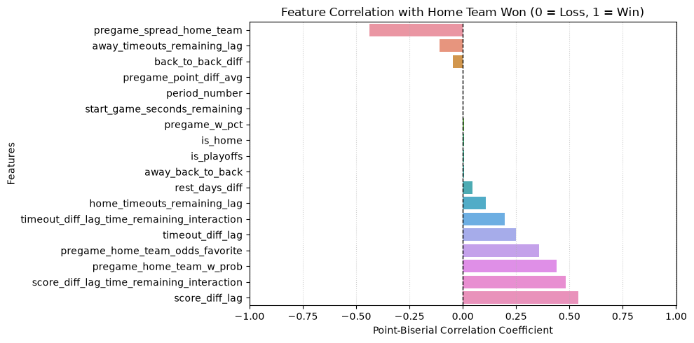

```python
numerical_features = ["score_diff_lag","start_game_seconds_remaining","score_diff_lag_time_remaining_interaction","period_number","is_playoffs","is_home","pregame_home_team_w_prob",
                      "home_timeouts_remaining_lag","away_timeouts_remaining_lag","timeout_diff_lag","timeout_diff_lag_time_remaining_interaction","pregame_w_pct",
                      "away_back_to_back","back_to_back_diff","rest_days_diff","pregame_point_diff_avg","pregame_spread_home_team","pregame_home_team_odds_favorite"]
plot_feature_correlation_vs_target(merged_df2, numerical_features)
```

### 5. Model Building

Due to time constraints, I limited my choice of machine learning algorithms to just XGBoost without comparing to any other binary classification model. This model has been the industry standard for some time as having strong predictive power as it is able to discover complex feature interactions and handle mixed continuous/binary/categorical features without heavy preprocessing as well as missing values.

Since each season has plenty of in-game play-by-play data, I decided to use all of 2025 (reg season + playoffs) as the train set and 2026 as the holdout validation set to make predictions on. It is important to call out that each row is not fully independent as plays within a single game are correlated. Therefore, a random k fold cross validation (CV) setup does not suffice, so I utilized grouped 5-fold cross validation instead grouped on game_id. Cross validation is applied within the train set where 4/5th of the train data is split for training and the remaining 1/5 used for testing. The model is fit five times until each datapoint has been used for testing. The model that minimizes average log loss across the 5 test splits will be the final, best model. This grouped 5-fold CV approach ensures that no single game's rows ever appear on both sides of a split during cross validation. I used a manual grid search for hyper-parameter tuning to find the best parameters that minimzed log loss. After fitting the model on the training data and finding the best parameters that mimized logloss through cross validation of the train set, the best paramaters model was used to make predictions on the 2026 validation set. Isotonic calibration and monotonic constraints on certain features were both part of an earlier, more rigorous version of this pipeline, then explicitly removed to produce a simpler baseline to start from.

Below are performance metrics (accuracy, recall, precision, f1 score, log loss, brier score) resulting from predictions on the test set. I also compute the same error using ESPN's own live in-game win probability model as a check to make sure model leakage is not an issue and calibration to be similar to that of ESPN. I believe using ESPN's pregame odds in the model itself is the main reason why performance is similar as both models would start in a similar pregame state. We also see the confusion table printed looking at frequency and proportion of games from a binary win/loss perspective using 0.5 as the decision threshold for home team winning.

```
Train X's Dim:  (616159, 18)
Train Y Dim:  (616159,)
Test X's Dim:  (633672, 18)
Test Y Dim:  (633672,)
Total Rows:  1249831
Fitting 5 folds for each of 48 candidates, totalling 240 fits
Best CV logloss: 0.4523
Best params: {'learning_rate': 0.005, 'max_depth': 3, 'n_estimators': 900}

=== Test set performance ===
  accuracy: 0.7774
 precision: 0.7943
    recall: 0.8086
        f1: 0.8014
   logloss: 0.4450
     brier: 0.1476

=== ESPN Win Prob Test set performance ===
  accuracy: 0.7766
 precision: 0.7964
    recall: 0.8029
        f1: 0.7996
   logloss: 0.4434
     brier: 0.1480

=== Classification report (threshold = 0.50) ===
              precision    recall  f1-score   support

    Away win       0.76      0.74      0.75    281804
    Home win       0.79      0.81      0.80    351868

    accuracy                           0.78    633672
   macro avg       0.77      0.77      0.77    633672
weighted avg       0.78      0.78      0.78    633672
```

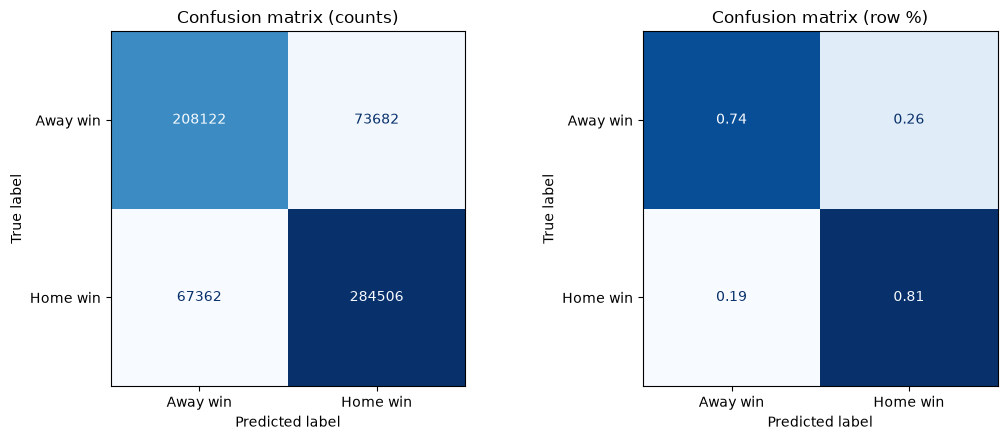

```python
# Define target variable (Y)
y_col = "home_team_won"

# Define features (Xs)
feature_cols = ["score_diff_lag","start_game_seconds_remaining","score_diff_lag_time_remaining_interaction","period_number","is_playoffs","is_home","pregame_home_team_w_prob",
                "home_timeouts_remaining_lag","away_timeouts_remaining_lag","timeout_diff_lag","timeout_diff_lag_time_remaining_interaction","pregame_w_pct",
                "away_back_to_back","back_to_back_diff","rest_days_diff","pregame_point_diff_avg","pregame_spread_home_team","pregame_home_team_odds_favorite"]

# Define hyper-parameter grid to use
param_grid = {
    "max_depth": [3,4,5],
    "learning_rate": [0.005, 0.015, 0.02, 0.05],
    "n_estimators": [300,500,700,900],
}

mod = run_nba_wp_model(merged_df2, 2025, 2026, feature_cols, param_grid)
test = mod['test_df']
```

### 6. Analyzing Model Output

This plot below is a model feature importance plot which ranks features the model actually leaned on most heavily when constructing its decision splits. The expectation, per basketball logic, is that score difference and time remaining in the game should dominate. We see that the top two most important features by far are the interaction between score differential lagged and time remaining as well as the pregame home team win probability converted from ESPN moneyline odds. We also see pregame spread as well as the team difference in rest days as important features. This confirms the model isn't purely reactive to only in-game state — it's carrying forward real pregame information about relative team strength, rest status, regular season vs playoffs indicator throughout the entire game, not just at tipoff.

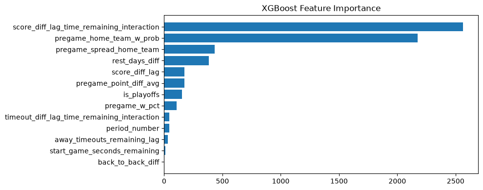

```python
importance_dict = mod['model'].get_booster().get_score(importance_type='weight')
importance_df = (
    pd.DataFrame(importance_dict.items(), columns=['feature', 'gain'])
    .sort_values('gain', ascending=True)
)
plt.figure(figsize=(10, 4))
plt.barh(importance_df['feature'], importance_df['gain'])
plt.title('XGBoost Feature Importance')
plt.tight_layout()
plt.show()
```

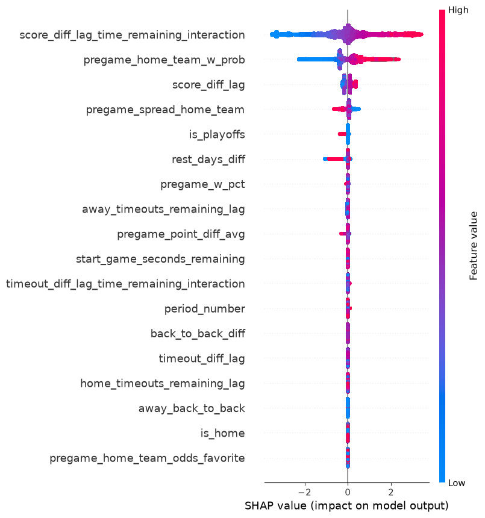

```python
# beeswarm summary plot -- each dot is one possession, color = feature value,
# x-position = that feature's SHAP contribution to that row's prediction
print_plot_middle()
explainer = shap.TreeExplainer(mod['model'])
shap_values = explainer.shap_values(mod["test_df"][feature_cols])
shap.summary_plot(shap_values, mod["test_df"][feature_cols])
```

In terms of model calibration, it is important to check if a 70% model prediction generates the correct prediction 70% of the time which is what a well-calibrated model achieves. Plotted across 20 probability bins, this is the direct visual test of whether the model's stated confidence matches reality — a well-calibrated model's curve should sit close to the 45-degree reference line across the full range. In our case, the model does sit along the diagonal line with some slight under-prediction around 50% and 85-90% win probability.

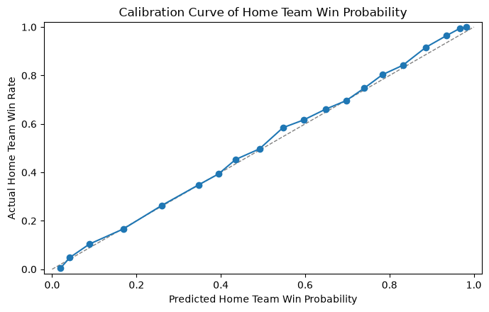

```python
print_plot_middle()
plot_calibration(test['home_team_won'], test["pred_home_team_win_prob_lag"], n_bins=20, width = 7, height = 4.5)
```

Lastly, I was curious to visualize how much of the pregame odds for home team winning influenced the starting prediction point for the game. Without any adjustments to matchup strength, I would expect home team win probability at the start of each game to hover closer to 50/50. But if we look at the scatterplot below isolating each game's first possession and comparing model predictions against the pregame odds from ESPN, the correlation coefficient is very strong, confirming the pregame features are doing real work from the opening tipoff. It's also color-coded so we can see the many high pregame/first play probabilities for home team did result in a home team victory and vice versa for the away team as green dots dominate top right and black dots dominate bottom left.

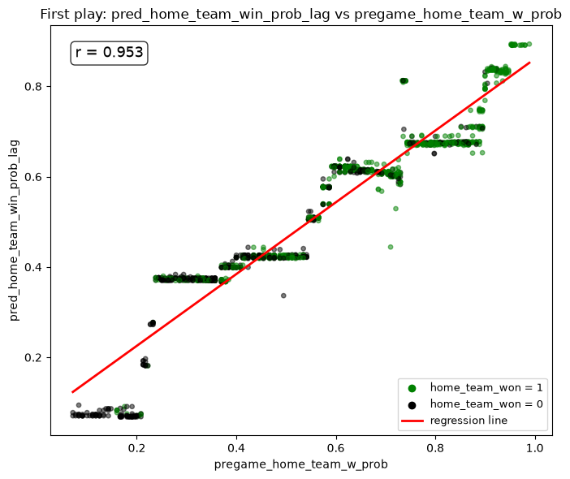

```python
plot_first_play_correlation(test)
```

### 7. Using the Model for WPA Analysis on 2026 Validation Set

Now that we have a win probability, we can analyze win probability added (WPA) which is simply the win probability immediately after a possession minus the win probability immediately before it. The difference represents the change in win probability as a result of the play. We expect the magnitude of in WPA to be smaller early in games and larger late in games, especially the 4th quarter. And any changes in score differential such as a 3pt play should have the largest effect on win probability as well as scoring in general. Let's take a look at the magnitude or absolute value of WPA across different states in the game (lagged score differential interacted with seconds left in the game at possession start).

This heatmap shows where in the state space — combinations of score margin lagged and time remaining in the game — a single play carries the most weight toward the final outcome. The expected pattern is a concentration of high mean |WPA| in the corner where time is short and the margin is close, fading to near-zero everywhere else (early game, or any point where the margin is already decisive). This is the direct visual confirmation that the model's sense of "leverage" matches actual basketball intuition about when moments matter most.

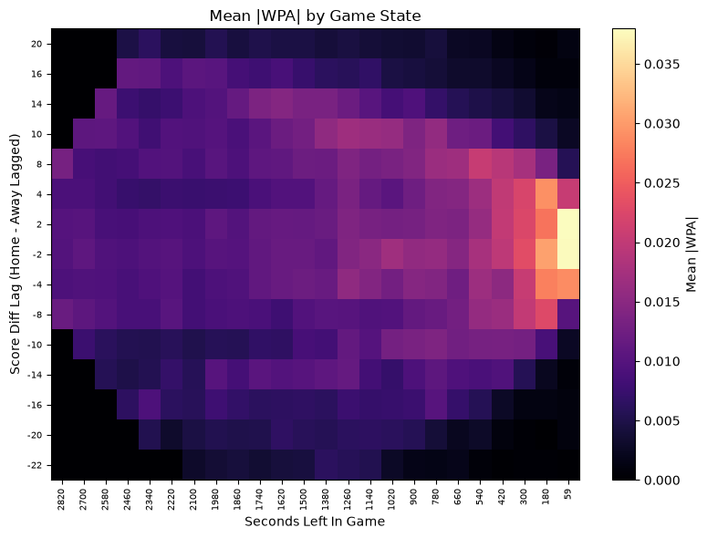

```python
plot_wpa_heatmap(test, n_time_bins = 24)
```

In terms of player ranking on WPA, we can aggregate in two different ways...

- **Total WPA** — cumulative, *not* adjusted for opportunity; naturally larger for players who played more possessions. Answers "how much real winning value did this player's actual role produce."
- **WPA per 100 possessions** — opportunity-adjusted; answers "how effective is this player independent of how much they played."

These intentionally answer different questions and are visualized together: a leaderboard comparing top-20 by each, and an interactive quadrant scatter plot (rate vs. total, bubble size = possessions) that separates "established, high-volume value" from "efficient but underused" from "propped up by usage" players.

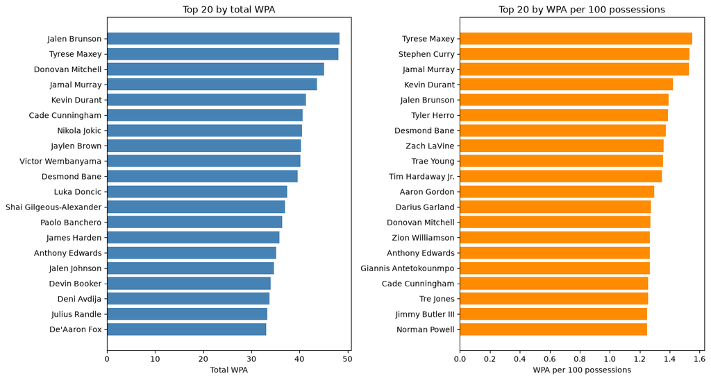

```python
players_agg = aggregate_player_wpa(test)
plot_wpa_leaderboard(players_agg)
```

In the plot below, the dotted black lines that create the 4 quadrants are the median values for total WPA and WPA per 100 possessions. The plot has an exponential growth shape to it as the top right set of players represent the elite (high efficieny and high volume of +WPA). Moving down from the top-right quadrant, the bottom right group depicts high efficiency players but a bit underrated due to lack of possession or scoring opportunities. Any player below the medians most likely did not have enough opportunities to make a significant impact on cumulating positive WPA.

```python
fig = plot_wpa_quadrant_plotly(players_agg, name_col="player_name")
```

[interactive chart not shown]

Let's also view WPA top rankings when filtering for 4th quarter and OT only to observe who was most clutch this past season (min. 300 possessions). In terms of efficiency on a per possession opportunity basis as the main consumer of the play, we see Kevin Durant had the highest WPA per possession adjusted for playing time in the league. This list checks out seeing some of the highest scorers in the league and best players among the top 20 (KD, SGA, Maxey, Curry, Jokic, Brunson, Ant Man, Giannis, etc.)

```python
tab = aggregate_player_wpa(test[test['period_number']>=4]).sort_values('wpa_per_100',  ascending = False)
tab[tab['possessions']>=300].head(20).round(2).map(lambda x: f"{x:.2f}".lstrip('0') if isinstance(x, (int, float)) else x)
```

|  | player_name | position | wpa_total | possessions | wpa_per_100 |
| --- | --- | --- | --- | --- | --- |
| 300 | Kevin Durant | F | 14.84 | 609.00 | 2.44 |
| 503 | Tyrese Maxey | G | 18.47 | 775.00 | 2.38 |
| 485 | Tre Jones | G | 8.18 | 344.00 | 2.38 |
| 214 | Jamal Murray | G | 18.10 | 764.00 | 2.37 |
| 306 | Keyonte George | G | 10.19 | 439.00 | 2.32 |
| 454 | Shai Gilgeous-Alexander | G | 13.88 | 603.00 | 2.30 |
| 460 | Stephen Curry | G | 8.77 | 398.00 | 2.20 |
| 108 | Darius Garland | G | 6.87 | 319.00 | 2.15 |
| 384 | Nikola Jokic | C | 15.55 | 723.00 | 2.15 |
| 328 | Lauri Markkanen | F | 7.59 | 363.00 | 2.09 |
| 127 | Desmond Bane | G | 15.89 | 804.00 | 1.98 |
| 203 | Jalen Brunson | G | 15.13 | 766.00 | 1.98 |
| 442 | Ryan Rollins | G | 10.08 | 522.00 | 1.93 |
| 29 | Anthony Edwards | G | 11.96 | 620.00 | 1.93 |
| 387 | Nikola Vucevic | C | 9.27 | 487.00 | 1.90 |
| 164 | Giannis Antetokounmpo | F | 7.91 | 421.00 | 1.88 |
| 238 | Jerami Grant | F | 8.27 | 441.00 | 1.88 |
| 65 | Cade Cunningham | G | 15.46 | 831.00 | 1.86 |
| 350 | Matas Buzelis | F | 9.72 | 523.00 | 1.86 |
| 443 | Saddiq Bey | G | 10.32 | 572.00 | 1.80 |

Analyzing a specific Kevin Durant game, this plot below traces one specific game's full win-probability curve and highlights the possessions where Kevin Durant's actions produced the top 4 largest swings. In this case, the top 4 |WPA| all resulted in positive win probability swings for his team, with his 3-point game winner vs Suns with 1 second left adding nearly 30% win probability to ice the game. Also printed is the corresponding dataset rows for these four plays along with a clickable link to the game-winning shot.

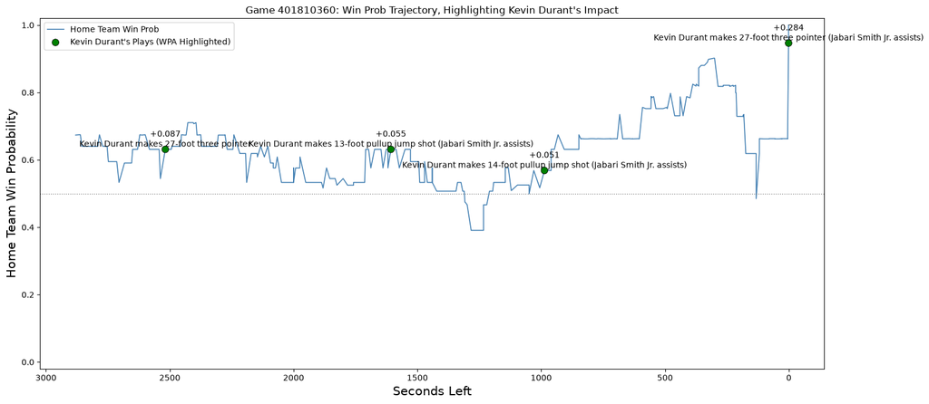

```
DF Shape: 4 rows and 12 cols
```

|  | game_date | home_team_abbrev | away_team_abbrev | period_number | clock_display_value | home_score | away_score | text | short_description | pred_home_team_win_prob_lag | pred_home_team_win_prob | win_probability_added |
| --- | --- | --- | --- | --- | --- | --- | --- | --- | --- | --- | --- | --- |
| 249501 | 2026-01-05 | HOU | PHX | 4 | 0:1.1 | 100 | 97 | Kevin Durant makes 27-foot three pointer (Jaba... | +3 Points | 0.662166 | 0.946516 | 0.284350 |
| 249109 | 2026-01-05 | HOU | PHX | 1 | 5:58 | 12 | 16 | Kevin Durant makes 27-foot three pointer | +3 Points | 0.544485 | 0.631162 | 0.086677 |
| 249255 | 2026-01-05 | HOU | PHX | 2 | 2:47 | 50 | 53 | Kevin Durant makes 13-foot pullup jump shot (J... | +2 Points | 0.576001 | 0.631162 | 0.055161 |
| 249343 | 2026-01-05 | HOU | PHX | 3 | 4:27 | 72 | 76 | Kevin Durant makes 14-foot pullup jump shot (J... | +2 Points | 0.517111 | 0.568474 | 0.051362 |

[figure not shown]

```python
plot_game_win_prob_with_player_highlights(test, 401810360, 'Kevin Durant', text_col='text')
HTML('''
<a href="https://www.youtube.com/watch?v=m0qudg-vYGw" target="_blank">
  <img src="https://img.youtube.com/vi/m0qudg-vYGw/hqdefault.jpg"
       alt="Click to watch on YouTube" style="max-width:600px;">
</a>
''')
```

Diving into the 2025-2026 Brooklyn Nets roster along with Julius Randle (new acquisition), we can see how Nets players stack up amongst each other in WPA rankings. Julius Randle should be expected to play a major role in contributing towards winning as the veteran on the team.

```python
nets_players = test[test['team_abbrev']=='BKN']['player_name'].unique()
nets_players = np.append(nets_players, 'Julius Randle')
a = aggregate_player_wpa(test)
a[a['player_name'].isin(nets_players)].sort_values('wpa_per_100', ascending = False).round(3)
```

|  | player_name | position | wpa_total | possessions | wpa_per_100 |
| --- | --- | --- | --- | --- | --- |
| 279 | Julius Randle | F | 33.317001 | 3408 | 0.978 |
| 360 | Michael Porter Jr. | F | 18.790001 | 1954 | 0.962 |
| 152 | Egor Demin | G | 8.482000 | 1006 | 0.843 |
| 342 | Malachi Smith | G | 1.858000 | 224 | 0.830 |
| 504 | Tyrese Martin | G | 4.911000 | 604 | 0.813 |
| 391 | Noah Clowney | F | 11.791000 | 1591 | 0.741 |
| 393 | Nolan Traore | G | 7.717000 | 1073 | 0.719 |
| 398 | Ochai Agbaji | G | 5.267000 | 756 | 0.697 |
| 529 | Ziaire Williams | F | 7.006000 | 1057 | 0.663 |
| 472 | Terance Mann | G | 6.440000 | 1033 | 0.623 |
| 141 | Drake Powell | G | 5.399000 | 866 | 0.623 |
| 507 | Tyson Etienne | G | 2.028000 | 326 | 0.622 |
| 113 | Day'Ron Sharpe | C | 8.286000 | 1361 | 0.609 |
| 380 | Nic Claxton | C | 10.822000 | 1786 | 0.606 |
| 151 | E.J. Liddell | F | 1.808000 | 317 | 0.570 |
| 39 | Ben Saraf | G | 4.338000 | 783 | 0.554 |
| 107 | Danny Wolf | F | 6.521000 | 1198 | 0.544 |
| 271 | Josh Minott | F | 3.922000 | 727 | 0.539 |
| 213 | Jalen Wilson | F | 3.931000 | 739 | 0.532 |
| 490 | Trevon Scott | F | 0.444000 | 122 | 0.364 |
| 78 | Chaney Johnson | F | 1.062000 | 332 | 0.320 |

Lastly, I evaluated specific play types within the data and check which ones are most beneficial and detrimental towards winning. Sorting by average WPA in ascending order, we see bad events such as violations, turnovers, fouls, and missed shots contribute negatively towards winning on average as expected. However, their magnitude or signficance in affecting WPA on a singular play-by-play basis is much lower than scoring. Shooting and scoring in today's game I believe is the single most important factor in determining winning. We have seen the NBA transform into a 3pt shooting league where teams are attempting a record number of three point shots and it's reflected in WPA calculations. This does not mean turnovers are non-significant, especially in late game situations. But stronger teams against weaker competition are able to commit turnovers early in games that don't cost the team much in terms of winning.

```python
test2 = test[~test['short_description'].isin(['Not Available','Ejection','Jump Ball','Challenge','Substitution'])]
test2 = test2[test2['period_number']<=4]
test2.groupby(['short_description']).agg(
    total_wpa=('win_probability_added', 'sum'),
    average_wpa=('win_probability_added', 'mean'),
    num_possessions=('short_description', 'size')
).reset_index().sort_values('average_wpa', ascending = True)
```

|  | short_description | total_wpa | average_wpa | num_possessions |
| --- | --- | --- | --- | --- |
| 11 | Violation | -1.280411 | -0.000811 | 1578 |
| 10 | Turnover | -24.719049 | -0.000649 | 38111 |
| 3 | Foul | -19.362963 | -0.000360 | 53727 |
| 5 | Missed 3PT | -17.188803 | -0.000272 | 63150 |
| 6 | Missed FG | -15.241816 | -0.000247 | 61760 |
| 7 | Missed FT | -1.115173 | -0.000083 | 13478 |
| 8 | Rebound | 8.278219 | 0.000060 | 138389 |
| 4 | Goaltending | 0.342903 | 0.000523 | 656 |
| 9 | Timeout | 35.198357 | 0.002499 | 14084 |
| 0 | +1 Point | 847.211182 | 0.017525 | 48342 |
| 1 | +2 Points | 2507.610352 | 0.033439 | 74990 |
| 2 | +3 Points | 1720.726807 | 0.049510 | 34755 |

If we aggregate WPA by team and separate into good vs bad play types and sort, we can learn which teams have the highest and lowest total WPA and how much of each total team WPA value is determined by shot making, rebounding, missed shots, and turnovers. It's worth pointing out that dominant teams that have high win probabilities pregame such as OKC Thunder appear at the bottom of WPA gained. This might be due to the fact that their pregame win probabilities were already skewed towards them to begin with, which results in lower magntudinal changes to their WPA play-by-play. They also played many non-competitive 4th quarters due to blowouts which hurts their ability to accumulate more WPA. Interestingly, Spurs were at the top of the rankings and LA Clippers were the outlier team in significantly losing more WPA from turnovers, fouls, and missed shots which could help explain why they started the season 6–21. And in terms of total WPA by team grouped by quarter, we see Spurs accumulated the most WPA in 4th quarters while teams that struggled to win games had much lower WPA contributions late in games.

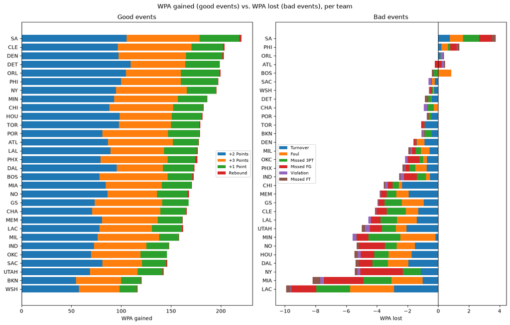

```python
plot_good_vs_bad_events(test)
```

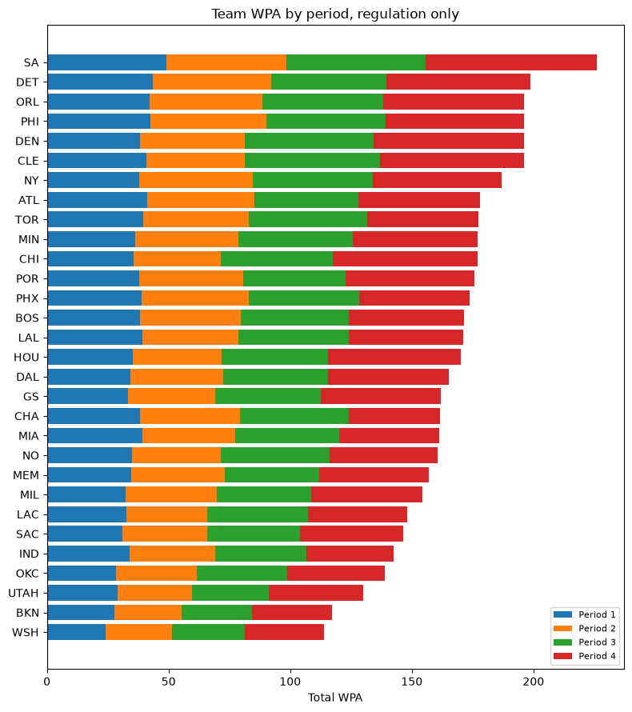

```python
plot_team_wpa_by_period(test)
```

## 8. Limitations and Next Steps

This project set out to answer whether an NBA win probability model could be built from public play-by-play data, whether it would hold up against an established ESPN benchmark, and whether the resulting win probability added (WPA) metric could surface meaningful signal for player and team evaluation.

Using two full seasons (2025 training, 2026 test — roughly 1.25 million possessions total) of sportsdataverse play-by-play data, an XGBoost model built on 18 engineered features — dominated by the lagged score-differential/time-remaining interaction and pregame win probability — achieved similar test set performance to that of ESPN's win probability models in large part due to including ESPN's pregame odds into the model. Calibration checks confirmed the model's predicted probabilities track real outcomes closely across the full range, with only slight under-prediction near 50% and in the 85-90% band.

Using this model, WPA was computed for every possession and aggregated to build player leaderboards (both total and per-100-possession), a team-level breakdown of good vs. bad event contributions, a period-by-period team profile, and individual game-level narratives (e.g., Kevin Durant's largest-impact plays in a specific game).

There are limitations in this analysis that need to be addressed:

- **Sample Size**: Two seasons is a reasonable starting point but is thin for clutch-specific reliability — a player's 4th-quarter/OT WPA ranking is based on a relatively small number of high-leverage possessions, and should be treated as provisional until validated on a longer multi-season window or checked for year-over-year persistence.
- **Defense Attribution**: Offensive WPA (shot-making, shot creation, drawing fouls) attributes cleanly to the main, acting player; defensive WPA (a defensive team stop, a forced miss, steals & blocks) is structurally harder to credit to one individual given scheme and teammate involvement, and should be read with more caution than the offensive numbers. This is why players such as Rudy Gobert or Draymond Green are undervalued in this analysis.
- **Teammate Attribution**: Teammates that set up a clean shot with their playmaking and smart offensive sets (fast breaks, transition offense, half-court offense) are ignored in this analysis. Creating a good shot is just as important as the shooter making the shot.
- **Calibration and Monotonicity**: The model shows real but modest miscalibration in specific probability bands (50%, 85-90%); isotonic calibration and monotonic constraints were deliberately left out of this version to keep the baseline simple, and would be the first thing to reintroduce if a more precise model were needed.
- **Results-Based Analysis**: Due to not having player tracking data, we are crediting WPA to plays without any context on shot quality or how a shot was created. A wide-open, uncontested shot created from an offensive set is a much better process than making a random, heavily contested heave at the end of the shot clock. However in this analysis, both situations would credit the player the same WPA.
- **Total WPA Limits**: As a cumulative metric, players logging heavy minutes and high usage rates naturally accumulate more opportunities to swing win probability positively. Missing in the creation of WPA are lack of context for shot quality and ignoring other teammates that did not attempt the shot or turnover the ball.

Next steps:

- Extend to additional seasons to build more reliable clutch-specific leaderboards and test whether player WPA rankings are actually persistent (a split-half or year-over-year correlation check) before treating them as a stable measure of skill rather than variance.
- Reintroduce isotonic calibration and monotonic constraints to address the specific probability bands where under-prediction was observed.
- Build a more rigorous possession-level (not play-level) attribution scheme, particularly for shared credit on rebounds and assists.
- Engineer more in-play features that capture scoring runs, consecutive defensive stops, shooting percentages, etc. to rely less on static pregame odds from ESPN for the model to better learn how on-court player/team performance affects win probability.